# Project 2

Hyunseok Lee

2024-10-14

## Data description

```r
df<- read.csv("C:/Users/Hyunseok/Downloads/stellar_temperature.csv")
summary(df)
```

```
##       teff           ra_x              dec_x            parallax
##  Min.   :3664   Min.   :  0.0043   Min.   :-85.713   Min.   : 0.1179
##  1st Qu.:4911   1st Qu.: 80.6802   1st Qu.:  9.583   1st Qu.: 0.6239
##  Median :5548   Median :131.7663   Median : 25.928   Median : 1.0460
##  Mean   :5518   Mean   :154.5872   Mean   : 23.149   Mean   : 1.4354
##  3rd Qu.:6018   3rd Qu.:231.4918   3rd Qu.: 39.772   3rd Qu.: 1.7423
##  Max.   :8631   Max.   :359.9147   Max.   : 85.299   Max.   :16.9419
##       pmra               pmdec               g_mag            b_mag
##  Min.   :-258.5010   Min.   :-207.1520   Min.   : 5.191   Min.   : 5.776
##  1st Qu.:  -5.9387   1st Qu.:  -9.3328   1st Qu.:12.777   1st Qu.:13.207
##  Median :  -0.9095   Median :  -4.0930   Median :13.878   Median :14.322
##  Mean   :  -1.6585   Mean   :  -6.0106   Mean   :13.831   Mean   :14.302
##  3rd Qu.:   3.1290   3rd Qu.:  -0.5092   3rd Qu.:14.983   3rd Qu.:15.481
##  Max.   : 188.1720   Max.   : 106.0590   Max.   :18.809   Max.   :19.448
##      r_mag            br_col               L                  B
##  Min.   : 4.564   Min.   :-0.08625   Min.   :  0.0385   Min.   :-89.23
##  1st Qu.:12.204   1st Qu.: 0.33404   1st Qu.: 91.5764   1st Qu.:-16.91
##  Median :13.287   Median : 0.42862   Median :163.1523   Median : 12.25
##  Mean   :13.222   Mean   : 0.47147   Mean   :154.3933   Mean   : 11.80
##  3rd Qu.:14.362   3rd Qu.: 0.57561   3rd Qu.:198.4155   3rd Qu.: 37.98
##  Max.   :18.689   Max.   : 2.27454   Max.   :359.9994   Max.   : 89.42
```

```r
colnames(df) # 12 columns include response variable
```

```
##  [1] "teff"     "ra_x"     "dec_x"    "parallax" "pmra"     "pmdec"
##  [7] "g_mag"    "b_mag"    "r_mag"    "br_col"   "L"        "B"
```

```r
nrow(df) # 10000 rows
```

```
## [1] 10000
```

```r
colSums(is.na(df)) # No NAs
```

```
##     teff     ra_x    dec_x parallax     pmra    pmdec    g_mag    b_mag
##        0        0        0        0        0        0        0        0
##    r_mag   br_col        L        B
##        0        0        0        0
```

There are 12 columns include response variable and the data shape is 10000 rows and 12 cols. There is no ‘NA’ values in all columns.

## EDA

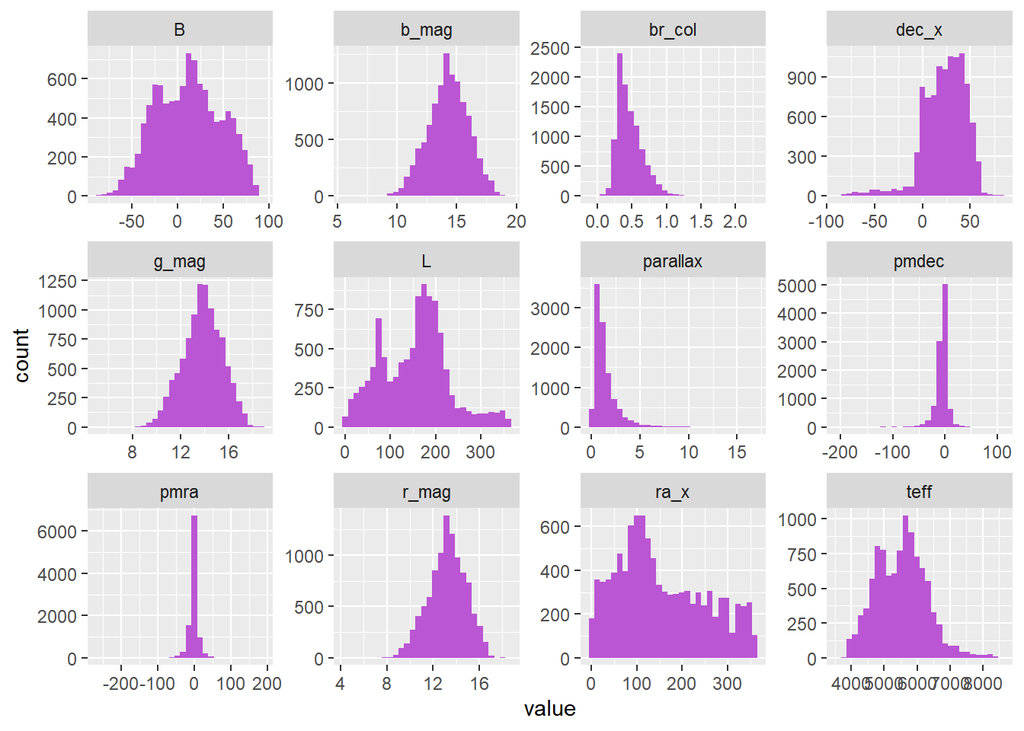

```r
# Outlier
## Histogram
suppressMessages(library(tidyverse))
df %>% gather(.) -> df.eda
ggplot(data = df.eda, mapping = aes(x=value)) +
  geom_histogram(fill = "mediumorchid") +
  facet_wrap(~key, scales = 'free') # parallax, br_col predictors look skewed
```

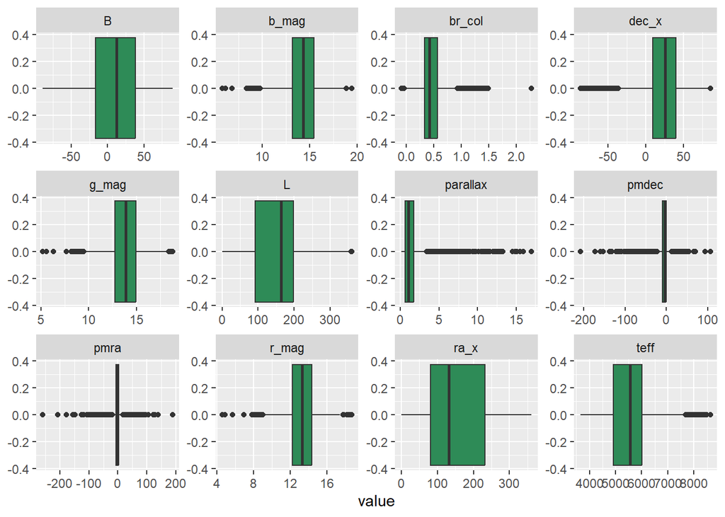

```r
# response variable looks normal distributed


ggplot(data = df.eda, mapping = aes(x=value)) +
  geom_boxplot(fill = "seagreen") +
  facet_wrap(~key, scales = 'free')
```

```r
detectoutlier <- function(x) {
  # Remove missing values
  x <- x[!is.na(x)]
  mean_val <- mean(x)
  sd_val <- sd(x)
  # Identify outliers based on z-scores ( 4 is way higher than normal)
  abs(x - mean_val) > (4 * sd_val)
}
# Remove outliers
removeoutlier <- function(dataframe, columns=names(dataframe)) {
  for (col in columns) {
    dataframe <- dataframe[!detectoutlier(dataframe[[col]]),]
  }
  dataframe
}

sum(detectoutlier(df$g_mag)=='TRUE')
```

```
## [1] 3
```

```r
sum(detectoutlier(df$pmra)=='TRUE')
```

```
## [1] 91
```

```r
sum(detectoutlier(df$parallax)=='TRUE')
```

```
## [1] 93
```

```r
sum(detectoutlier(df$b_mag)=='TRUE')
```

```
## [1] 3
```

```r
sum(detectoutlier(df$br_col)=='TRUE')
```

```
## [1] 29
```

```r
sum(detectoutlier(df$dec_x)=='TRUE')
```

```
## [1] 60
```

```r
sum(detectoutlier(df$pmdec)=='TRUE')
```

```
## [1] 79
```

```r
sum(detectoutlier(df$r_mag)=='TRUE')
```

```
## [1] 3
```

```r
df.new <- removeoutlier(df, c('g_mag', 'pmra', 'parallax','b_mag','br_col','dec_x','pmdec','r_mag'))
nrow(df.new) # 354 rows were deleted
```

```
## [1] 9646
```

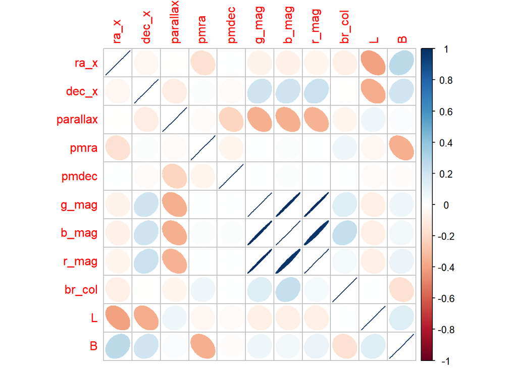

```r
# Correlation
suppressMessages(library(corrplot))
df.new %>% select(.,-teff) %>% cor(.) %>% corrplot(.,method = 'ellipse')
```

```r
# b_mag & g_mag % r_mag are highly correlated
```

Before we remove the outliers, I used ggplot to determine transformation of response variable. Since our response variable looks normal distribution, there is no transformation needed. I made outlier function based on z-score, and I used extreme high value which is sigma is 4. The 354 rows were deleted. For correlation plot, g_mag, b_mag, r_mag are highly correlated to other variable(s).

## Train & test set

```r
set.seed(600)

s <- sample(nrow(df.new),round(0.8*nrow(df.new)))
df.train<-df.new[s,]
df.test<-df.new[-s,]
```

```
Set training set as 80% and test set as 20% of whole dataset.(Included response variable)
```

## Linear model

```r
m1 <- lm(teff~., data = df.train)
summary(m1)
```

```
##
## Call:
## lm(formula = teff ~ ., data = df.train)
##
## Residuals:
##     Min      1Q  Median      3Q     Max
## -1100.0  -273.3   -82.6   148.6  4461.8
##
## Coefficients: (1 not defined because of singularities)
##               Estimate Std. Error t value Pr(>|t|)
## (Intercept)  8.286e+03  6.726e+01 123.192  < 2e-16 ***
## ra_x        -4.490e-01  6.629e-02  -6.773 1.35e-11 ***
## dec_x        5.264e+00  2.898e-01  18.166  < 2e-16 ***
## parallax    -9.621e+01  5.645e+00 -17.044  < 2e-16 ***
## pmra         5.127e-01  5.027e-01   1.020    0.308
## pmdec        2.745e+00  5.573e-01   4.925 8.61e-07 ***
## g_mag       -4.386e+03  4.481e+02  -9.787  < 2e-16 ***
## b_mag        1.109e+02  2.043e+02   0.543    0.587
## r_mag        4.262e+03  2.466e+02  17.281  < 2e-16 ***
## br_col              NA         NA      NA       NA
## L            6.083e-01  9.239e-02   6.584 4.89e-11 ***
## B           -4.245e+00  1.820e-01 -23.326  < 2e-16 ***
## ---
## Signif. codes:  0 '***' 0.001 '**' 0.01 '*' 0.05 '.' 0.1 ' ' 1
##
## Residual standard error: 452.2 on 7706 degrees of freedom
## Multiple R-squared:  0.6558, Adjusted R-squared:  0.6553
## F-statistic:  1468 on 10 and 7706 DF,  p-value: < 2.2e-16
```

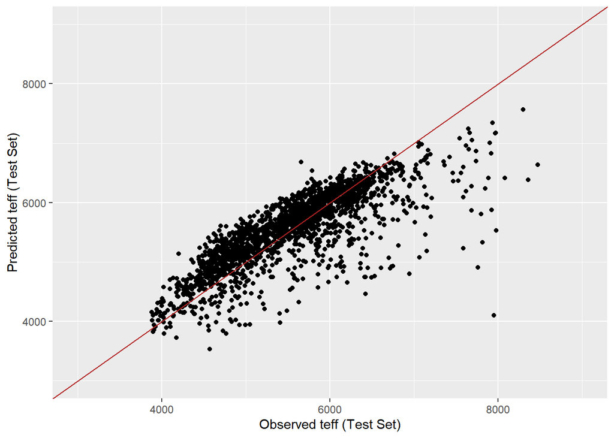

```r
# mean square error and root mean squared error :

teff.pred <- predict(m1,newdata=df.test)
df.plot   <- data.frame("x"=df.test$teff,"y"=teff.pred)
ggplot(data=df.plot,mapping=aes(x=x,y=y)) +
  geom_point() + xlim(3000,9000) + ylim(3000,9000) +
  geom_abline(intercept=0,slope=1,color="firebrick") +
  xlab("Observed teff (Test Set)") +
  ylab("Predicted teff (Test Set)") # looks ok
```

```r
mean((teff.pred-df.test$teff)^2)
```

```
## [1] 213827
```

```r
lm.mse<-mean((teff.pred-df.test$teff)^2)
mean((teff.pred-df.test$teff))
```

```
## [1] -5.200828
```

## Residual plot

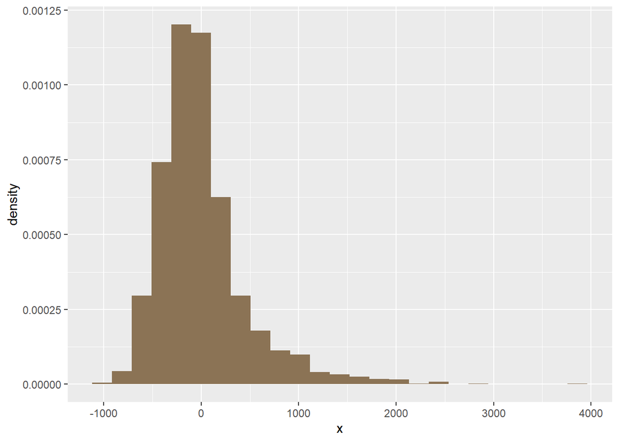

```r
df.plot   <- data.frame("x"=df.test$teff-teff.pred)
ggplot(data=df.plot,mapping=aes(x=x)) +
  geom_histogram(bins=25,fill="burlywood4",aes(y=after_stat(density)))
```

```r
shapiro.test(df.plot$x)$p.value
```

```
## [1] 2.253966e-37
```

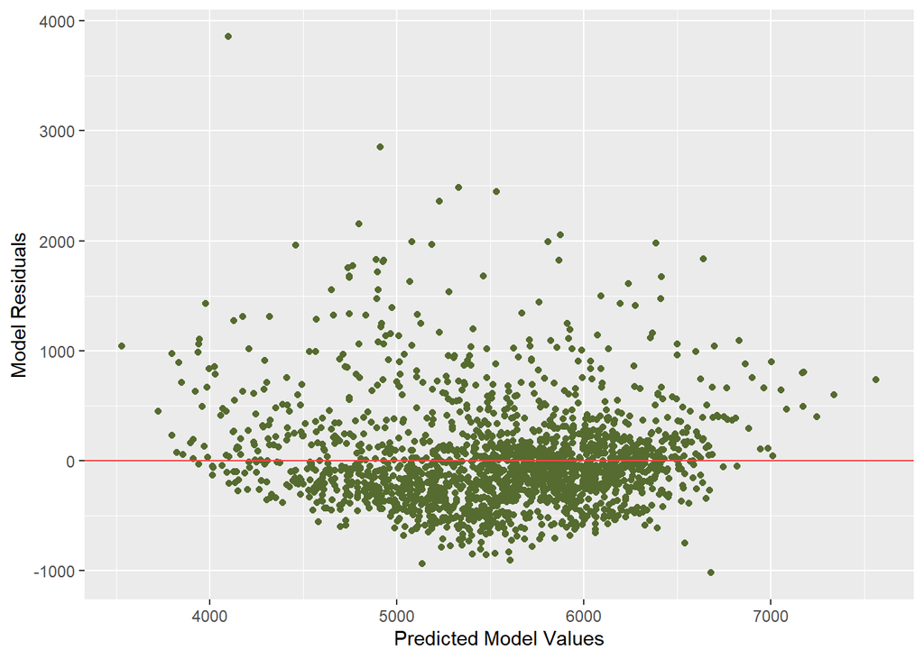

```r
# Since P-value is 2.253966e-37 < 0.05, so we reject the null hypothesis that the data are normally distributed.

# Check Variance constant
df.plot <- data.frame("x"=teff.pred,"y"=df.test$teff-teff.pred)
ggplot(data=df.plot,mapping=aes(x=x,y=y)) +
  geom_point(col="darkolivegreen") +
  geom_hline(yintercept=0,col="brown1") +
  xlab("Predicted Model Values") + ylab("Model Residuals")
```

```r
# Maybe No
car::ncvTest(m1)
```

```
## Non-constant Variance Score Test
## Variance formula: ~ fitted.values
## Chisquare = 167.0336, Df = 1, p = < 2.22e-16
```

```r
# Since p-value is < 2.22e-16, we reject the null hypothesis that the variance is constant
```

Since residual plot’s P-value is 2.253966e-37 < 0.05, so we reject the null hypothesis that the data are normally distributed. Also, a plot of the residuals versus the predicted test-set response values are not even around the regression line. + When we run ncv.Test(), p-value is < 2.22e-16, we reject the null hypothesis that the variance is constant. As a result, we need to transfrom our response variable.

## Log- transformation on response variable

```r
df.train$teff<-log10(df.train$teff) # Transform response variable
df.test$teff<-log10(df.test$teff)

# Linear model
tm1 <- lm(teff~., data = df.train)
summary(tm1)
```

```
##
## Call:
## lm(formula = teff ~ ., data = df.train)
##
## Residuals:
##      Min       1Q   Median       3Q      Max
## -0.08334 -0.02090 -0.00507  0.01221  0.32114
##
## Coefficients: (1 not defined because of singularities)
##               Estimate Std. Error t value Pr(>|t|)
## (Intercept)  3.945e+00  5.058e-03 779.970  < 2e-16 ***
## ra_x        -3.566e-05  4.985e-06  -7.153 9.30e-13 ***
## dec_x        4.016e-04  2.179e-05  18.429  < 2e-16 ***
## parallax    -7.689e-03  4.245e-04 -18.112  < 2e-16 ***
## pmra         4.150e-05  3.780e-05   1.098    0.272
## pmdec        1.934e-04  4.191e-05   4.613 4.02e-06 ***
## g_mag       -1.765e-01  3.370e-02  -5.238 1.66e-07 ***
## b_mag       -7.135e-02  1.536e-02  -4.644 3.47e-06 ***
## r_mag        2.465e-01  1.855e-02  13.289  < 2e-16 ***
## br_col              NA         NA      NA       NA
## L            4.587e-05  6.948e-06   6.602 4.32e-11 ***
## B           -3.250e-04  1.368e-05 -23.749  < 2e-16 ***
## ---
## Signif. codes:  0 '***' 0.001 '**' 0.01 '*' 0.05 '.' 0.1 ' ' 1
##
## Residual standard error: 0.03401 on 7706 degrees of freedom
## Multiple R-squared:  0.6835, Adjusted R-squared:  0.6831
## F-statistic:  1664 on 10 and 7706 DF,  p-value: < 2.2e-16
```

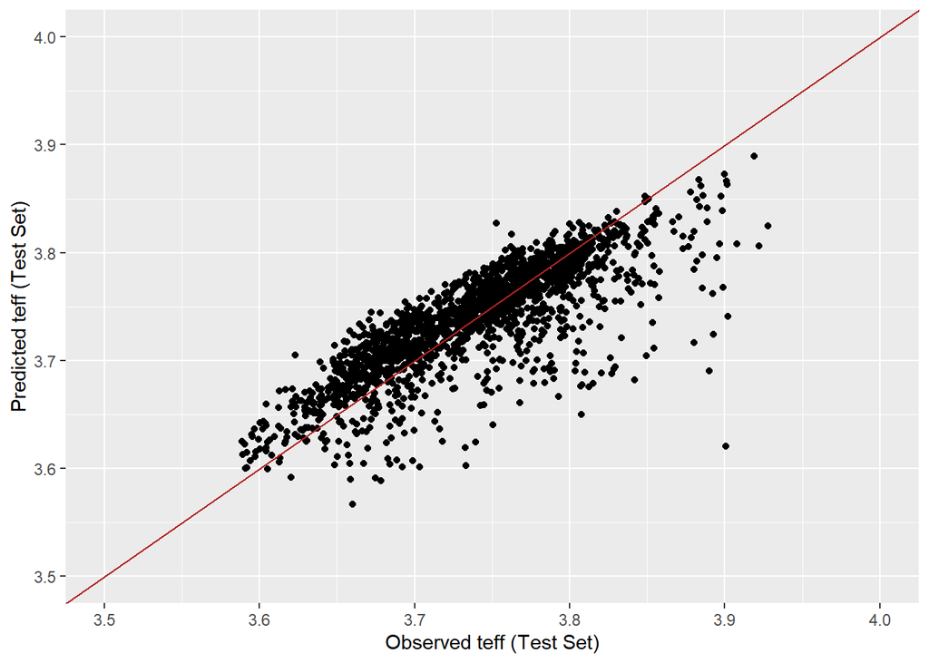

```r
# mean square error and root mean squared error :

teff.pred <- predict(tm1,newdata=df.test)
df.plot   <- data.frame("x"=df.test$teff,"y"=teff.pred)
ggplot(data=df.plot,mapping=aes(x=x,y=y)) +
  geom_point() + xlim(3.5,4) + ylim(3.5,4) +
  geom_abline(intercept=0,slope=1,color="firebrick") +
  xlab("Observed teff (Test Set)") +
  ylab("Predicted teff (Test Set)") # looks ok
```

```r
mean((teff.pred-df.test$teff)^2)
```

```
## [1] 0.001216886
```

```r
lm.mse<-mean((teff.pred-df.test$teff)^2)
mean((teff.pred-df.test$teff))
```

```
## [1] -0.0004707068
```

## VIF

```r
suppressMessages(library(car))
vif(tm1) # Something aliased variables
```

```
## Error in vif.default(tm1): there are aliased coefficients in the model
```

```r
attributes(alias(tm1)$Complete)$dimnames[[1]] # br-col is the dependent variable
```

```
## [1] "br_col"
```

```r
vif(lm(teff~.-br_col, data = df.train)) # VIF without br_col columns
```

```
##         ra_x        dec_x     parallax         pmra        pmdec        g_mag
##     1.573037     1.461643     1.221324     1.162404     1.063606 19537.523961
##        b_mag        r_mag            L            B
##  4236.965893  5742.821460     1.759650     1.539942
```

```r
# g_mag, b_mag, r_mag are the potentially problematic variables
```

When we compute variance-inflation factor function it said there are aliased coefficient in the model which mean there are dependent variable in our predictors. So I defined our dependent variable by using attributes function and it gave ‘br-col’ predictor. After remove this predictor, our result shows that g_mag, b_mag, r_mag are the potentially problematic variable since it has high values in VIF. But we are gonna keep it.